# 06-SQL-In-Jupyter-Notebook

```python
%load_ext sql
```

%load_ext sql

```python
import os
```

import os

## Connecting to the database

```python
host = "localhost"
database = "sdb"
user = os.getenv('SQL_USER')
password = os.getenv('SQL_PASSWORD')
```

host = "localhost" database = "sdb" user = os.getenv('SQL_USER') password = os.getenv('SQL_PASSWORD')

```python
connection_string = f"postgresql://{user}:{password}@{host}/{database}"
%sql $connection_string
```

connection_string = f"postgresql://{user}:{password}@{host}/{database}" %sql $connection_string

```
'Connected: postgres@sdb'
```

```python
%%sql

SELECT * FROM cities5000 LIMIT 10
```

%%sql SELECT * FROM cities5000 LIMIT 10

```
 * postgresql://postgres:***@localhost/sdb
10 rows affected.
```

| id | geonameid | name | asciiname | alternatenames | latitude | longitude | feature_class | feature_code | country_code | cc2 | admin1_code | admin2_code | admin3_code | admin4_code | population | elevation | dem | timezone | modification_date |
| --- | --- | --- | --- | --- | --- | --- | --- | --- | --- | --- | --- | --- | --- | --- | --- | --- | --- | --- | --- |
| 1 | 3039163 | Sant Julià de Lòria | Sant Julia de Loria | San Julia,San Julià,Sant Julia de Loria,Sant Julià de Lòria,Sant-Zhulija-de-Lorija,sheng hu li ya-de luo li ya,Сант-Жулия-де-Лория,サン・ジュリア・デ・ロリア教区,圣胡利娅-德洛里亚,圣胡利娅－德洛里亚 | 42.46372 | 1.49129 | P | PPLA | AD |  | 06 |  |  |  | 8022 |  | 921 | Europe/Andorra | 2013-11-23 |
| 2 | 3039678 | Ordino | Ordino | Ordino,ao er di nuo,orudino jiao qu,Ордино,オルディノ教区,奥尔迪诺 | 42.55623 | 1.53319 | P | PPLA | AD |  | 05 |  |  |  | 3066 |  | 1296 | Europe/Andorra | 2018-10-26 |
| 3 | 3040051 | les Escaldes | les Escaldes | Ehskal'des-Ehndzhordani,Escaldes,Escaldes-Engordany,Les Escaldes,esukarudesu=engorudani jiao qu,lai sai si ka er de-en ge er da,Эскальдес-Энджордани,エスカルデス＝エンゴルダニ教区,萊塞斯卡爾德-恩戈爾達,萊塞斯卡爾德－恩戈爾達 | 42.50729 | 1.53414 | P | PPLA | AD |  | 08 |  |  |  | 15853 |  | 1033 | Europe/Andorra | 2008-10-15 |
| 4 | 3040132 | la Massana | la Massana | La Macana,La Massana,La Maçana,La-Massana,la Massana,ma sa na,Ла-Массана,ラ・マサナ教区,马萨纳 | 42.54499 | 1.51483 | P | PPLA | AD |  | 04 |  |  |  | 7211 |  | 1245 | Europe/Andorra | 2008-10-15 |
| 5 | 3040686 | Encamp | Encamp | Ehnkam,Encamp,en kan pu,enkanpu jiao qu,Энкам,エンカンプ教区,恩坎普 | 42.53474 | 1.58014 | P | PPLA | AD |  | 03 |  |  |  | 11223 |  | 1257 | Europe/Andorra | 2018-10-26 |
| 6 | 3041204 | Canillo | Canillo | Canillo,Kanil'o,ka ni e,kaniryo jiao qu,Канильо,カニーリョ教区,卡尼略 | 42.5676 | 1.59756 | P | PPLA | AD |  | 02 |  |  |  | 3292 |  | 1561 | Europe/Andorra | 2018-10-26 |
| 7 | 3041563 | Andorra la Vella | Andorra la Vella | ALV,Ando-la-Vyey,Andora,Andora la Vela,Andora la Velja,Andora lja Vehl'ja,Andoro Malnova,Andorra,Andorra Tuan,Andorra a Vella,Andorra la Biella,Andorra la Vella,Andorra la Vielha,Andorra-a-Velha,Andor… | 42.50779 | 1.52109 | P | PPLC | AD |  | 07 |  |  |  | 20430 |  | 1037 | Europe/Andorra | 2020-03-03 |
| 8 | 290594 | Umm Al Quwain City | Umm Al Quwain City | Oumm al Qaiwain,Oumm al Qaïwaïn,Um al Kawain,Um al Quweim,Umm Al Quwain City,Umm al Qaiwain,Umm al Qawain,Umm al Qaywayn,Umm al-Quwain,Umm-ehl'-Kajvajn,Yumul al Quwain,am alqywyn,mdynt am alqywyn,Умм-… | 25.56473 | 55.55517 | P | PPLA | AE |  | 07 |  |  |  | 62747 |  | 2 | Asia/Dubai | 2019-10-24 |
| 9 | 291074 | Ras Al Khaimah City | Ras Al Khaimah City | Julfa,Khaimah,RAK City,RKT,Ra's al Khaymah,Ra's al-Chaima,Ras Al Khaimah City,Ras al Khaimah,Ras al-Khaimah,Ras el Khaimah,Ras el Khaïmah,Ras el-Kheima,Ras-ehl'-Khajma,Ra’s al Khaymah,Ra’s al-Chaima,m… | 25.78953 | 55.9432 | P | PPLA | AE |  | 05 |  |  |  | 351943 |  | 2 | Asia/Dubai | 2019-09-09 |
| 10 | 291279 | Muzayri‘ | Muzayri` | Mezaira'a,Mezaira’a,Mizeir`ah,Mizeir‘ah,Mozayri`,Mozayri‘,Muzairi,Muzayri`,Muzayri‘,Музаири | 23.14355 | 53.7881 | P | PPL | AE |  | 01 |  |  |  | 10000 |  | 123 | Asia/Dubai | 2013-10-24 |

## The SQL SELECT statement

```python
%%sql

SELECT name, country_code, dem FROM cities5000
WHERE country_code LIKE 'C_'
ORDER BY dem DESC
LIMIT 10
```

%%sql SELECT name, country_code, dem FROM cities5000 WHERE country_code LIKE 'C_' ORDER BY dem DESC LIMIT 10

```
 * postgresql://postgres:***@localhost/sdb
10 rows affected.
```

| name | country_code | dem |
| --- | --- | --- |
| Nagqu | CN | 4512 |
| Jiangzi | CN | 4036 |
| Dêqên | CN | 3974 |
| Burang | CN | 3892 |
| Rikaze | CN | 3847 |
| Daocheng | CN | 3756 |
| Lhasa | CN | 3651 |
| Gahai | CN | 3546 |
| Awancang | CN | 3504 |
| Maima | CN | 3495 |

```python
%%sql

SELECT DISTINCT country_code FROM cities5000
LIMIT 10
```

%%sql SELECT DISTINCT country_code FROM cities5000 LIMIT 10

```
 * postgresql://postgres:***@localhost/sdb
10 rows affected.
```

| country_code |
| --- |
| RU |
| FK |
| KP |
| DK |
| SN |
| SI |
| PN |
| CZ |
| KR |
| VE |

```python
%%sql

SELECT COUNT(DISTINCT country_code) FROM cities5000
```

%%sql SELECT COUNT(DISTINCT country_code) FROM cities5000

```
 * postgresql://postgres:***@localhost/sdb
1 rows affected.
```

| count |
| --- |
| 245 |

```python
%%sql

SELECT MAX(dem) FROM cities5000
```

%%sql SELECT MAX(dem) FROM cities5000

```
 * postgresql://postgres:***@localhost/sdb
1 rows affected.
```

| max |
| --- |
| 5022 |

```python
%%sql

SELECT SUM(population) FROM cities5000;
```

%%sql SELECT SUM(population) FROM cities5000;

```
 * postgresql://postgres:***@localhost/sdb
(psycopg2.errors.UndefinedFunction) function sum(character varying) does not exist
LINE 1: SELECT SUM(population) FROM cities5000;
               ^
HINT:  No function matches the given name and argument types. You might need to add explicit type casts.

[SQL: SELECT SUM(population) FROM cities5000;]
(Background on this error at: http://sqlalche.me/e/14/f405)
```

```python
%%sql

SELECT SUM(CAST(population AS INTEGER)) FROM cities5000;
```

%%sql SELECT SUM(CAST(population AS INTEGER)) FROM cities5000;

```
 * postgresql://postgres:***@localhost/sdb
1 rows affected.
```

| sum |
| --- |
| 3228361637 |

```python
%%sql

SELECT AVG(CAST(population AS INTEGER)) FROM cities5000;
```

%%sql SELECT AVG(CAST(population AS INTEGER)) FROM cities5000;

```
 * postgresql://postgres:***@localhost/sdb
1 rows affected.
```

| avg |
| --- |
| 62503.371415848677 |

```python
%%sql

SELECT name, country_code, dem, CAST(population AS INTEGER) FROM cities5000
ORDER BY dem DESC, population DESC
LIMIT 10
```

%%sql SELECT name, country_code, dem, CAST(population AS INTEGER) FROM cities5000 ORDER BY dem DESC, population DESC LIMIT 10

```
 * postgresql://postgres:***@localhost/sdb
10 rows affected.
```

| name | country_code | dem | population |
| --- | --- | --- | --- |
| La Rinconada | PE | 5022 | 29678 |
| La Rinconada Ana Maria (La Rinconada) | PE | 5016 | 12183 |
| Lobujya | NP | 4972 | 8767 |
| Hacienda Huancane | PE | 4531 | 7831 |
| Nagqu | CN | 4512 | 30000 |
| Morococha | PE | 4512 | 7890 |
| Macusani | PE | 4360 | 6044 |
| Yanacancha | PE | 4348 | 24105 |
| Cerro de Pasco | PE | 4336 | 78910 |
| Paragsha- San Andres - Jose Carlos Mariategui | PE | 4336 | 6316 |

## The WHERE Clause

```python
%%sql

SELECT * FROM cities5000 WHERE country_code='US' LIMIT 10
```

%%sql SELECT * FROM cities5000 WHERE country_code='US' LIMIT 10

```
 * postgresql://postgres:***@localhost/sdb
10 rows affected.
```

| id | geonameid | name | asciiname | alternatenames | latitude | longitude | feature_class | feature_code | country_code | cc2 | admin1_code | admin2_code | admin3_code | admin4_code | population | elevation | dem | timezone | modification_date |
| --- | --- | --- | --- | --- | --- | --- | --- | --- | --- | --- | --- | --- | --- | --- | --- | --- | --- | --- | --- |
| 45910 | 4702785 | Keene | Keene |  | 32.39681 | -97.3239 | P | PPL | US |  | TX | 251 |  |  | 6181 | 272.0 | 279 | America/Chicago | 2017-03-09 |
| 43474 | 4046255 | Bay Minette | Bay Minette | Bay Minette,Bay Minette Station,Bej Minet,Bej-Minett,bay mynyty,be minetta,bei mi nei te,by mynt,Бей-Мінетт,Беј Минет,باي مينيتي,بی مینت,बे मिनेत्त,贝米内特 | 30.88296 | -87.77305 | P | PPLA2 | US |  | AL | 003 |  |  | 9118 | 82.0 | 85 | America/Chicago | 2017-03-09 |
| 43475 | 4046274 | Edna | Edna | Edna,Ednaville,Macaroni Station,adna,adna tgzas,Една,إدنا,ادنا، تگزاس | 28.97859 | -96.64609 | P | PPLA2 | US |  | TX | 239 |  |  | 5792 | 20.0 | 24 | America/Chicago | 2017-03-09 |
| 43476 | 4046332 | Henderson | Henderson | Khenderson,hndrswn,hndrswn tgzas,Хендерсон,هندرسون,هندرسون، تگزاس | 32.15322 | -94.79938 | P | PPLA2 | US |  | TX | 401 |  |  | 13529 | 156.0 | 160 | America/Chicago | 2017-03-09 |
| 43477 | 4046704 | Fort Hunt | Fort Hunt |  | 38.73289 | -77.05803 | P | PPL | US |  | VA | 059 |  |  | 16045 | 10.0 | 16 | America/New_York | 2011-05-14 |
| 43478 | 4047906 | Trinity | Trinity |  | 28.18085 | -82.68177 | P | PPL | US |  | FL | 101 |  |  | 10907 | 6.0 | 15 | America/New_York | 2011-05-14 |
| 43479 | 4047914 | Villas | Villas |  | 26.55035 | -81.8687 | P | PPL | US |  | FL | 071 |  |  | 11569 | 3.0 | 6 | America/New_York | 2011-05-14 |
| 43480 | 4048023 | Bessemer | Bessemer | Besemer,Bessemer,bei se mo,bes'semara,beseomeo,bsmr,bysmyr,Бесемер,Бессемер,بسمر,بيسمير,बेस्सेमर,贝瑟默,베서머 | 33.40178 | -86.95444 | P | PPL | US |  | AL | 073 |  |  | 26730 | 155.0 | 161 | America/Chicago | 2017-03-09 |
| 43481 | 4048662 | Paducah | Paducah | PAH,Padaka,Padjuka,Paducah,Paduka,Pekin,badwka,pa di you ka,padeyuka,pdwka kntaky,peodyuka,Падака,Падука,Падјука,بادوكا,پاڈوکاہ، کینٹکی,پدوکا، کنتاکی,パデューカ,帕迪尤卡,퍼듀카 | 37.08339 | -88.60005 | P | PPLA2 | US |  | KY | 145 |  |  | 24864 | 104.0 | 104 | America/Chicago | 2018-01-03 |
| 43482 | 4048888 | Red Chute | Red Chute |  | 32.55598 | -93.61323 | P | PPL | US |  | LA | 015 |  |  | 6261 | 65.0 | 67 | America/Chicago | 2011-05-14 |

```python
%%sql

SELECT * FROM cities5000 WHERE country_code='US' OR country_code='CA' LIMIT 5
```

%%sql SELECT * FROM cities5000 WHERE country_code='US' OR country_code='CA' LIMIT 5

```
 * postgresql://postgres:***@localhost/sdb
5 rows affected.
```

| id | geonameid | name | asciiname | alternatenames | latitude | longitude | feature_class | feature_code | country_code | cc2 | admin1_code | admin2_code | admin3_code | admin4_code | population | elevation | dem | timezone | modification_date |
| --- | --- | --- | --- | --- | --- | --- | --- | --- | --- | --- | --- | --- | --- | --- | --- | --- | --- | --- | --- |
| 5902 | 5901272 | Binbrook | Binbrook |  | 43.12135 | -79.81104 | P | PPLX | CA |  | 08 | 3525 |  |  | 8796 |  | 216 | America/Toronto | 2018-01-20 |
| 5903 | 5903510 | Blainville | Blainville |  | 45.66678 | -73.88249 | P | PPL | CA |  | 10 | 15 | 73015 |  | 46493 |  | 73 | America/Toronto | 2019-02-26 |
| 5904 | 5904501 | Bluewater | Bluewater |  | 43.46679 | -81.59977 | P | PPL | CA |  | 08 |  |  |  | 7044 |  | 249 | America/Toronto | 2013-05-05 |
| 5872 | 5881791 | Abbotsford | Abbotsford | Abbotsford,Abotsford,Abotsfordas,YXX,abottsufodo,abwtsfwrd,abwtsfwrd brytysh klmbya,aebeocheupeodeu,ya bo si fu,Абботсфорд,Аботсфорд,أبوتسفورد,ابوتسفورد، بریتیش کلمبیا,ایباٹسفورڈ,ایبٹس فورڈ، برٹش کولم… | 49.05798 | -122.25257 | P | PPL | CA |  | 02 | 5909 | 5909052 |  | 141397 |  | 114 | America/Vancouver | 2021-12-05 |
| 5873 | 5882142 | Acton Vale | Acton Vale | Akton Veil,Akton Vejl,Aktonvejl,aktwn wal kbk,Άκτον Βέιλ,Актон Вејл,Актонвейл,اکتون وال، کبک,ایکٹن والی | 45.65007 | -72.56582 | P | PPL | CA |  | 10 | 16 | 48028 |  | 7656 |  | 90 | America/Toronto | 2021-11-12 |

```python
%%sql

SELECT name,population,country_code,dem FROM cities5000
WHERE country_code='US' AND CAST(population AS INTEGER)>1000000
```

%%sql SELECT name,population,country_code,dem FROM cities5000 WHERE country_code='US' AND CAST(population AS INTEGER)>1000000

```
 * postgresql://postgres:***@localhost/sdb
14 rows affected.
```

| name | population | country_code | dem |
| --- | --- | --- | --- |
| Philadelphia | 1567442 | US | 40 |
| Dallas | 1300092 | US | 139 |
| Houston | 2296224 | US | 30 |
| San Antonio | 1469845 | US | 202 |
| Chicago | 2720546 | US | 180 |
| The Bronx | 1385108 | US | 19 |
| Brooklyn | 2300664 | US | 18 |
| Manhattan | 1487536 | US | 38 |
| New York City | 8175133 | US | 57 |
| Queens | 2272771 | US | 13 |
| Phoenix | 1563025 | US | 366 |
| Los Angeles | 3971883 | US | 96 |
| San Diego | 1394928 | US | 20 |
| San Jose | 1026908 | US | 23 |

```python
%%sql

SELECT name,population,country_code,dem  FROM cities5000
WHERE name LIKE 'U%' LIMIT 5
```

%%sql SELECT name,population,country_code,dem FROM cities5000 WHERE name LIKE 'U%' LIMIT 5

```
 * postgresql://postgres:***@localhost/sdb
5 rows affected.
```

| name | population | country_code | dem |
| --- | --- | --- | --- |
| Umm Al Quwain City | 62747 | AE | 2 |
| Uruzgān | 13388 | AF | 2026 |
| Uíge | 60008 | AO | 825 |
| Uacu Cungo | 10970 | AO | 1304 |
| Urdinarrain | 7992 | AR | 68 |

```python
%%sql

SELECT name,population,country_code,dem FROM cities5000
WHERE country_code LIKE 'C_' LIMIT 10
```

%%sql SELECT name,population,country_code,dem FROM cities5000 WHERE country_code LIKE 'C_' LIMIT 10

```
 * postgresql://postgres:***@localhost/sdb
10 rows affected.
```

| name | population | country_code | dem |
| --- | --- | --- | --- |
| Sinfra | 59919 | CI | 265 |
| Hekou | 47281 | CN | 41 |
| Songlou | 79763 | CN | 40 |
| Sunlou | 46941 | CN | 40 |
| Zhuzhai | 56908 | CN | 40 |
| Wanchao | 12067 | CN | 835 |
| Binbrook | 8796 | CA | 216 |
| Blainville | 46493 | CA | 73 |
| Bluewater | 7044 | CA | 249 |
| Abbotsford | 141397 | CA | 114 |

```python
%%sql

SELECT name,population,country_code,dem FROM cities5000
WHERE name LIKE 'He__' LIMIT 10
```

%%sql SELECT name,population,country_code,dem FROM cities5000 WHERE name LIKE 'He__' LIMIT 10

```
 * postgresql://postgres:***@localhost/sdb
8 rows affected.
```

| name | population | country_code | dem |
| --- | --- | --- | --- |
| Hepu | 192813 | CN | 12 |
| Hepo | 131238 | CN | 41 |
| Heze | 1346717 | CN | 53 |
| Hede | 89107 | CN | 2 |
| Hebi | 634721 | CN | 138 |
| Heba | 32538 | CN | 1772 |
| Heek | 8272 | DE | 52 |
| Heer | 7615 | NL | 58 |

```python
%%sql

SELECT name,population,country_code,dem FROM cities5000
WHERE dem BETWEEN 3500 AND 3600
```

%%sql SELECT name,population,country_code,dem FROM cities5000 WHERE dem BETWEEN 3500 AND 3600

```
 * postgresql://postgres:***@localhost/sdb
6 rows affected.
```

| name | population | country_code | dem |
| --- | --- | --- | --- |
| Gahai | 5257 | CN | 3546 |
| Awancang | 6619 | CN | 3504 |
| Padam | 25000 | IN | 3560 |
| Leh | 37475 | IN | 3502 |
| Sicuani | 33575 | PE | 3551 |
| San Miguel de Cauri | 5326 | PE | 3586 |

## SQL Joins

Reference: https://www.w3schools.com/sql/sql_join.asp

Here are the different types of the JOINs in SQL:

- **(INNER) JOIN**: Returns records that have matching values in both tables
- **LEFT (OUTER) JOIN**: Returns all records from the left table, and the matched records from the right table
- **RIGHT (OUTER) JOIN**: Returns all records from the right table, and the matched records from the left table
- **FULL (OUTER) JOIN**: Returns all records when there is a match in either left or right table

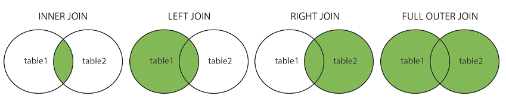

Get number of rows

```python
%%sql

SELECT COUNT(*) FROM cities
```

%%sql SELECT COUNT(*) FROM cities

```
 * postgresql://postgres:***@localhost/sdb
1 rows affected.
```

| count |
| --- |
| 1249 |

```python
%%sql

SELECT * FROM cities LIMIT 10
```

%%sql SELECT * FROM cities LIMIT 10

```
 * postgresql://postgres:***@localhost/sdb
10 rows affected.
```

| id | name | country | latitude | longitude | population |
| --- | --- | --- | --- | --- | --- |
| 1 | Bombo | UGA | 0.5833 | 32.5333 | 75000 |
| 2 | Fort Portal | UGA | 0.671 | 30.275 | 42670 |
| 3 | Potenza | ITA | 40.642 | 15.799 | 69060 |
| 4 | Campobasso | ITA | 41.563 | 14.656 | 50762 |
| 5 | Aosta | ITA | 45.737 | 7.315 | 34062 |
| 6 | Mariehamn | ALD | 60.097 | 19.949 | 10682 |
| 7 | Ramallah | PSE | 31.90294 | 35.20621 | 24599 |
| 8 | Vatican City | VAT | 41.90001 | 12.44781 | 832 |
| 9 | Poitier | FRA | 46.58329 | 0.33328 | 85960 |
| 10 | Clermont-Ferrand | FRA | 45.77998 | 3.08001 | 233050 |

```python
%%sql

SELECT COUNT(*) FROM countries
```

%%sql SELECT COUNT(*) FROM countries

```
 * postgresql://postgres:***@localhost/sdb
1 rows affected.
```

| count |
| --- |
| 243 |

```python
%%sql

SELECT * FROM countries LIMIT 10
```

%%sql SELECT * FROM countries LIMIT 10

```
 * postgresql://postgres:***@localhost/sdb
10 rows affected.
```

| id | Country | Alpha2_code | Alpha3_code | Numeric_code | Latitude | Longitude |
| --- | --- | --- | --- | --- | --- | --- |
| 1 | Afghanistan | AF | AFG | 4 | 33 | 65 |
| 2 | Albania | AL | ALB | 8 | 41 | 20 |
| 3 | Algeria | DZ | DZA | 12 | 28 | 3 |
| 4 | American Samoa | AS | ASM | 16 | -14.3333 | -170 |
| 5 | Andorra | AD | AND | 20 | 42.5 | 1.6 |
| 6 | Angola | AO | AGO | 24 | -12.5 | 18.5 |
| 7 | Anguilla | AI | AIA | 660 | 18.25 | -63.1667 |
| 8 | Antarctica | AQ | ATA | 10 | -90 | 0 |
| 9 | Antigua and Barbuda | AG | ATG | 28 | 17.05 | -61.8 |
| 10 | Argentina | AR | ARG | 32 | -34 | -64 |

### Inner Join

```python
%%sql

SELECT * FROM cities INNER JOIN countries ON cities.country = countries."Alpha3_code" LIMIT 10
```

%%sql SELECT * FROM cities INNER JOIN countries ON cities.country = countries."Alpha3_code" LIMIT 10

```
 * postgresql://postgres:***@localhost/sdb
10 rows affected.
```

| id | name | country | latitude | longitude | population | id_1 | Country | Alpha2_code | Alpha3_code | Numeric_code | Latitude | Longitude |
| --- | --- | --- | --- | --- | --- | --- | --- | --- | --- | --- | --- | --- |
| 1 | Bombo | UGA | 0.5833 | 32.5333 | 75000 | 226 | Uganda | UG | UGA | 800 | 1 | 32 |
| 2 | Fort Portal | UGA | 0.671 | 30.275 | 42670 | 226 | Uganda | UG | UGA | 800 | 1 | 32 |
| 3 | Potenza | ITA | 40.642 | 15.799 | 69060 | 106 | Italy | IT | ITA | 380 | 42.8333 | 12.8333 |
| 4 | Campobasso | ITA | 41.563 | 14.656 | 50762 | 106 | Italy | IT | ITA | 380 | 42.8333 | 12.8333 |
| 5 | Aosta | ITA | 45.737 | 7.315 | 34062 | 106 | Italy | IT | ITA | 380 | 42.8333 | 12.8333 |
| 7 | Ramallah | PSE | 31.90294 | 35.20621 | 24599 | 167 | Palestinian Territory, Occupied | PS | PSE | 275 | 32 | 35.25 |
| 8 | Vatican City | VAT | 41.90001 | 12.44781 | 832 | 94 | Holy See (Vatican City State) | VA | VAT | 336 | 41.9 | 12.45 |
| 9 | Poitier | FRA | 46.58329 | 0.33328 | 85960 | 72 | France | FR | FRA | 250 | 46 | 2 |
| 10 | Clermont-Ferrand | FRA | 45.77998 | 3.08001 | 233050 | 72 | France | FR | FRA | 250 | 46 | 2 |
| 11 | Besancon | FRA | 47.23 | 6.03001 | 128426 | 72 | France | FR | FRA | 250 | 46 | 2 |

```python
%%sql

SELECT name, country, countries."Country"
FROM cities INNER JOIN countries ON cities.country = countries."Alpha3_code"
LIMIT 20
```

%%sql SELECT name, country, countries."Country" FROM cities INNER JOIN countries ON cities.country = countries."Alpha3_code" LIMIT 20

```
 * postgresql://postgres:***@localhost/sdb
20 rows affected.
```

| name | country | Country |
| --- | --- | --- |
| Bombo | UGA | Uganda |
| Fort Portal | UGA | Uganda |
| Potenza | ITA | Italy |
| Campobasso | ITA | Italy |
| Aosta | ITA | Italy |
| Ramallah | PSE | Palestinian Territory, Occupied |
| Vatican City | VAT | Holy See (Vatican City State) |
| Poitier | FRA | France |
| Clermont-Ferrand | FRA | France |
| Besancon | FRA | France |
| Artigas Base | ATA | Antarctica |
| Chipata | ZMB | Zambia |
| Jinja | UGA | Uganda |
| Arua | UGA | Uganda |
| Mbale | UGA | Uganda |
| Moroto | UGA | Uganda |
| Masaka | UGA | Uganda |
| Mbarara | UGA | Uganda |
| Otjiwarongo | NAM | Namibia |
| Bologna | ITA | Italy |

### Left Join

```python
%%sql

SELECT * FROM cities LEFT JOIN countries ON cities.country = countries."Alpha3_code"
LIMIT 10
```

%%sql SELECT * FROM cities LEFT JOIN countries ON cities.country = countries."Alpha3_code" LIMIT 10

```
 * postgresql://postgres:***@localhost/sdb
10 rows affected.
```

| id | name | country | latitude | longitude | population | id_1 | Country | Alpha2_code | Alpha3_code | Numeric_code | Latitude | Longitude |
| --- | --- | --- | --- | --- | --- | --- | --- | --- | --- | --- | --- | --- |
| 1 | Bombo | UGA | 0.5833 | 32.5333 | 75000 | 226 | Uganda | UG | UGA | 800 | 1 | 32 |
| 2 | Fort Portal | UGA | 0.671 | 30.275 | 42670 | 226 | Uganda | UG | UGA | 800 | 1 | 32 |
| 3 | Potenza | ITA | 40.642 | 15.799 | 69060 | 106 | Italy | IT | ITA | 380 | 42.8333 | 12.8333 |
| 4 | Campobasso | ITA | 41.563 | 14.656 | 50762 | 106 | Italy | IT | ITA | 380 | 42.8333 | 12.8333 |
| 5 | Aosta | ITA | 45.737 | 7.315 | 34062 | 106 | Italy | IT | ITA | 380 | 42.8333 | 12.8333 |
| 6 | Mariehamn | ALD | 60.097 | 19.949 | 10682 | None | None | None | None | None | None | None |
| 7 | Ramallah | PSE | 31.90294 | 35.20621 | 24599 | 167 | Palestinian Territory, Occupied | PS | PSE | 275 | 32 | 35.25 |
| 8 | Vatican City | VAT | 41.90001 | 12.44781 | 832 | 94 | Holy See (Vatican City State) | VA | VAT | 336 | 41.9 | 12.45 |
| 9 | Poitier | FRA | 46.58329 | 0.33328 | 85960 | 72 | France | FR | FRA | 250 | 46 | 2 |
| 10 | Clermont-Ferrand | FRA | 45.77998 | 3.08001 | 233050 | 72 | France | FR | FRA | 250 | 46 | 2 |

### Right Join

```python
%%sql

SELECT * FROM cities RIGHT JOIN countries ON cities.country = countries."Alpha3_code"
LIMIT 10
```

%%sql SELECT * FROM cities RIGHT JOIN countries ON cities.country = countries."Alpha3_code" LIMIT 10

```
 * postgresql://postgres:***@localhost/sdb
10 rows affected.
```

| id | name | country | latitude | longitude | population | id_1 | Country | Alpha2_code | Alpha3_code | Numeric_code | Latitude | Longitude |
| --- | --- | --- | --- | --- | --- | --- | --- | --- | --- | --- | --- | --- |
| 1 | Bombo | UGA | 0.5833 | 32.5333 | 75000 | 226 | Uganda | UG | UGA | 800 | 1 | 32 |
| 2 | Fort Portal | UGA | 0.671 | 30.275 | 42670 | 226 | Uganda | UG | UGA | 800 | 1 | 32 |
| 3 | Potenza | ITA | 40.642 | 15.799 | 69060 | 106 | Italy | IT | ITA | 380 | 42.8333 | 12.8333 |
| 4 | Campobasso | ITA | 41.563 | 14.656 | 50762 | 106 | Italy | IT | ITA | 380 | 42.8333 | 12.8333 |
| 5 | Aosta | ITA | 45.737 | 7.315 | 34062 | 106 | Italy | IT | ITA | 380 | 42.8333 | 12.8333 |
| 7 | Ramallah | PSE | 31.90294 | 35.20621 | 24599 | 167 | Palestinian Territory, Occupied | PS | PSE | 275 | 32 | 35.25 |
| 8 | Vatican City | VAT | 41.90001 | 12.44781 | 832 | 94 | Holy See (Vatican City State) | VA | VAT | 336 | 41.9 | 12.45 |
| 9 | Poitier | FRA | 46.58329 | 0.33328 | 85960 | 72 | France | FR | FRA | 250 | 46 | 2 |
| 10 | Clermont-Ferrand | FRA | 45.77998 | 3.08001 | 233050 | 72 | France | FR | FRA | 250 | 46 | 2 |
| 11 | Besancon | FRA | 47.23 | 6.03001 | 128426 | 72 | France | FR | FRA | 250 | 46 | 2 |

### Full Join

```python
%%sql

SELECT * FROM cities FULL JOIN countries ON cities.country = countries."Alpha3_code"
LIMIT 10
```

%%sql SELECT * FROM cities FULL JOIN countries ON cities.country = countries."Alpha3_code" LIMIT 10

```
 * postgresql://postgres:***@localhost/sdb
10 rows affected.
```

| id | name | country | latitude | longitude | population | id_1 | Country | Alpha2_code | Alpha3_code | Numeric_code | Latitude | Longitude |
| --- | --- | --- | --- | --- | --- | --- | --- | --- | --- | --- | --- | --- |
| 1 | Bombo | UGA | 0.5833 | 32.5333 | 75000 | 226 | Uganda | UG | UGA | 800 | 1 | 32 |
| 2 | Fort Portal | UGA | 0.671 | 30.275 | 42670 | 226 | Uganda | UG | UGA | 800 | 1 | 32 |
| 3 | Potenza | ITA | 40.642 | 15.799 | 69060 | 106 | Italy | IT | ITA | 380 | 42.8333 | 12.8333 |
| 4 | Campobasso | ITA | 41.563 | 14.656 | 50762 | 106 | Italy | IT | ITA | 380 | 42.8333 | 12.8333 |
| 5 | Aosta | ITA | 45.737 | 7.315 | 34062 | 106 | Italy | IT | ITA | 380 | 42.8333 | 12.8333 |
| 6 | Mariehamn | ALD | 60.097 | 19.949 | 10682 | None | None | None | None | None | None | None |
| 7 | Ramallah | PSE | 31.90294 | 35.20621 | 24599 | 167 | Palestinian Territory, Occupied | PS | PSE | 275 | 32 | 35.25 |
| 8 | Vatican City | VAT | 41.90001 | 12.44781 | 832 | 94 | Holy See (Vatican City State) | VA | VAT | 336 | 41.9 | 12.45 |
| 9 | Poitier | FRA | 46.58329 | 0.33328 | 85960 | 72 | France | FR | FRA | 250 | 46 | 2 |
| 10 | Clermont-Ferrand | FRA | 45.77998 | 3.08001 | 233050 | 72 | France | FR | FRA | 250 | 46 | 2 |

### Union and Intersection

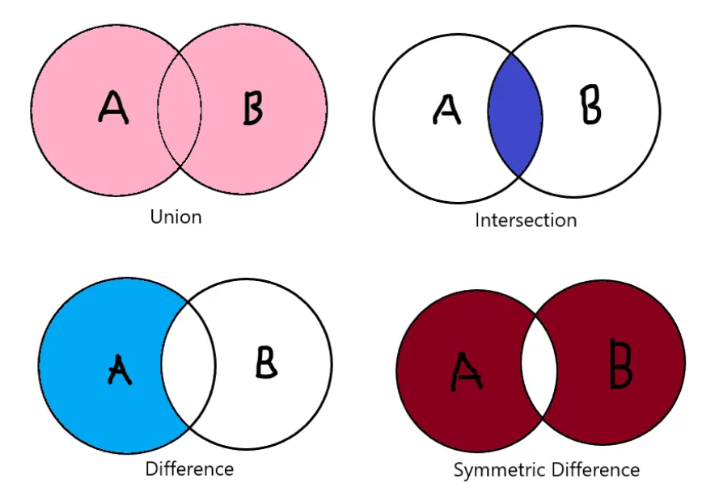

```python
%%sql

SELECT COUNT(country) FROM (
    SELECT country FROM cities
    INTERSECT
    SELECT "Alpha3_code" FROM countries
) AS intersection_result;
```

%%sql SELECT COUNT(country) FROM ( SELECT country FROM cities INTERSECT SELECT "Alpha3_code" FROM countries ) AS intersection_result;

```
 * postgresql://postgres:***@localhost/sdb
1 rows affected.
```

| count |
| --- |
| 196 |

```python
%%sql

SELECT COUNT(country) FROM (
    SELECT country FROM cities
    UNION
    SELECT "Alpha3_code" FROM countries
) AS union_result;
```

%%sql SELECT COUNT(country) FROM ( SELECT country FROM cities UNION SELECT "Alpha3_code" FROM countries ) AS union_result;

```
 * postgresql://postgres:***@localhost/sdb
1 rows affected.
```

| count |
| --- |
| 247 |

```python
%%sql

SELECT COUNT(country) AS difference_result  FROM cities
WHERE country NOT IN (SELECT "Alpha3_code" FROM countries);
```

%%sql SELECT COUNT(country) AS difference_result FROM cities WHERE country NOT IN (SELECT "Alpha3_code" FROM countries);

```
 * postgresql://postgres:***@localhost/sdb
1 rows affected.
```

| difference_result |
| --- |
| 5 |

## Aggregation

### Group By

```python
%%sql

SELECT COUNT(name), country
FROM cities
GROUP BY country
ORDER BY COUNT(name) DESC
LIMIT 10
```

%%sql SELECT COUNT(name), country FROM cities GROUP BY country ORDER BY COUNT(name) DESC LIMIT 10

```
 * postgresql://postgres:***@localhost/sdb
10 rows affected.
```

| count | country |
| --- | --- |
| 114 | USA |
| 100 | CHN |
| 81 | RUS |
| 69 | IND |
| 46 | BRA |
| 45 | CAN |
| 40 | ATA |
| 36 | AUS |
| 30 | FRA |
| 27 | MEX |

```python
%%sql

SELECT countries."Country", COUNT(name)
FROM cities
LEFT JOIN countries ON cities.country = countries."Alpha3_code"
GROUP BY countries."Country"
ORDER BY COUNT(name) DESC
LIMIT 10
```

%%sql SELECT countries."Country", COUNT(name) FROM cities LEFT JOIN countries ON cities.country = countries."Alpha3_code" GROUP BY countries."Country" ORDER BY COUNT(name) DESC LIMIT 10

```
 * postgresql://postgres:***@localhost/sdb
10 rows affected.
```

| Country | count |
| --- | --- |
| United States | 114 |
| China | 100 |
| Russia | 81 |
| India | 69 |
| Brazil | 46 |
| Canada | 45 |
| Antarctica | 40 |
| Australia | 36 |
| France | 30 |
| Mexico | 27 |

### Having

```python
%%sql

SELECT COUNT(name), countries."Country"
FROM cities
LEFT JOIN countries ON cities.country = countries."Alpha3_code"
GROUP BY countries."Country"
HAVING COUNT(name) > 40
ORDER BY COUNT(name) DESC
```

%%sql SELECT COUNT(name), countries."Country" FROM cities LEFT JOIN countries ON cities.country = countries."Alpha3_code" GROUP BY countries."Country" HAVING COUNT(name) > 40 ORDER BY COUNT(name) DESC

```
 * postgresql://postgres:***@localhost/sdb
6 rows affected.
```

| count | Country |
| --- | --- |
| 114 | United States |
| 100 | China |
| 81 | Russia |
| 69 | India |
| 46 | Brazil |
| 45 | Canada |

```python
%%sql

SELECT COUNT(name), country
FROM cities
GROUP BY country
HAVING COUNT(name) > 40
ORDER BY COUNT(name) DESC
```

%%sql SELECT COUNT(name), country FROM cities GROUP BY country HAVING COUNT(name) > 40 ORDER BY COUNT(name) DESC

```
 * postgresql://postgres:***@localhost/sdb
6 rows affected.
```

| count | country |
| --- | --- |
| 114 | USA |
| 100 | CHN |
| 81 | RUS |
| 69 | IND |
| 46 | BRA |
| 45 | CAN |

### Conditional statements

```python
%%sql

SELECT name, population,
CASE
    WHEN CAST(population AS INTEGER) > 10000000 THEN 'Megacity'
    WHEN CAST(population AS INTEGER) > 1000000 THEN 'Large city'
    ELSE 'Small city'
END AS category
FROM cities
LIMIT 20
```

%%sql SELECT name, population, CASE WHEN CAST(population AS INTEGER) > 10000000 THEN 'Megacity' WHEN CAST(population AS INTEGER) > 1000000 THEN 'Large city' ELSE 'Small city' END AS category FROM cities LIMIT 20

```
 * postgresql://postgres:***@localhost/sdb
20 rows affected.
```

| name | population | category |
| --- | --- | --- |
| Bombo | 75000 | Small city |
| Fort Portal | 42670 | Small city |
| Potenza | 69060 | Small city |
| Campobasso | 50762 | Small city |
| Aosta | 34062 | Small city |
| Mariehamn | 10682 | Small city |
| Ramallah | 24599 | Small city |
| Vatican City | 832 | Small city |
| Poitier | 85960 | Small city |
| Clermont-Ferrand | 233050 | Small city |
| Besancon | 128426 | Small city |
| Artigas Base | 60 | Small city |
| Chipata | 85963 | Small city |
| Jinja | 301619 | Small city |
| Arua | 250000 | Small city |
| Mbale | 402368 | Small city |
| Moroto | 371 | Small city |
| Masaka | 65373 | Small city |
| Mbarara | 83700 | Small city |
| Otjiwarongo | 24815 | Small city |

## Saving results

```python
%%sql

SELECT *
INTO cities_usa
FROM cities
WHERE country = 'USA'
```

%%sql SELECT * INTO cities_usa FROM cities WHERE country = 'USA'

```
 * postgresql://postgres:***@localhost/sdb
(psycopg2.errors.DuplicateTable) relation "cities_usa" already exists

[SQL: SELECT *
INTO cities_usa
FROM cities
WHERE country = 'USA']
(Background on this error at: http://sqlalche.me/e/14/f405)
```

## SQL Comments

### Single line coments

```python
%%sql

SELECT * FROM cities LIMIT 10 -- This is a comment;
```

%%sql SELECT * FROM cities LIMIT 10 -- This is a comment;

```
 * postgresql://postgres:***@localhost/sdb
10 rows affected.
```

| id | name | country | latitude | longitude | population |
| --- | --- | --- | --- | --- | --- |
| 1 | Bombo | UGA | 0.5833 | 32.5333 | 75000 |
| 2 | Fort Portal | UGA | 0.671 | 30.275 | 42670 |
| 3 | Potenza | ITA | 40.642 | 15.799 | 69060 |
| 4 | Campobasso | ITA | 41.563 | 14.656 | 50762 |
| 5 | Aosta | ITA | 45.737 | 7.315 | 34062 |
| 6 | Mariehamn | ALD | 60.097 | 19.949 | 10682 |
| 7 | Ramallah | PSE | 31.90294 | 35.20621 | 24599 |
| 8 | Vatican City | VAT | 41.90001 | 12.44781 | 832 |
| 9 | Poitier | FRA | 46.58329 | 0.33328 | 85960 |
| 10 | Clermont-Ferrand | FRA | 45.77998 | 3.08001 | 233050 |